# Bank Client Churn Prediction

### Distribution of estimated salary per churn

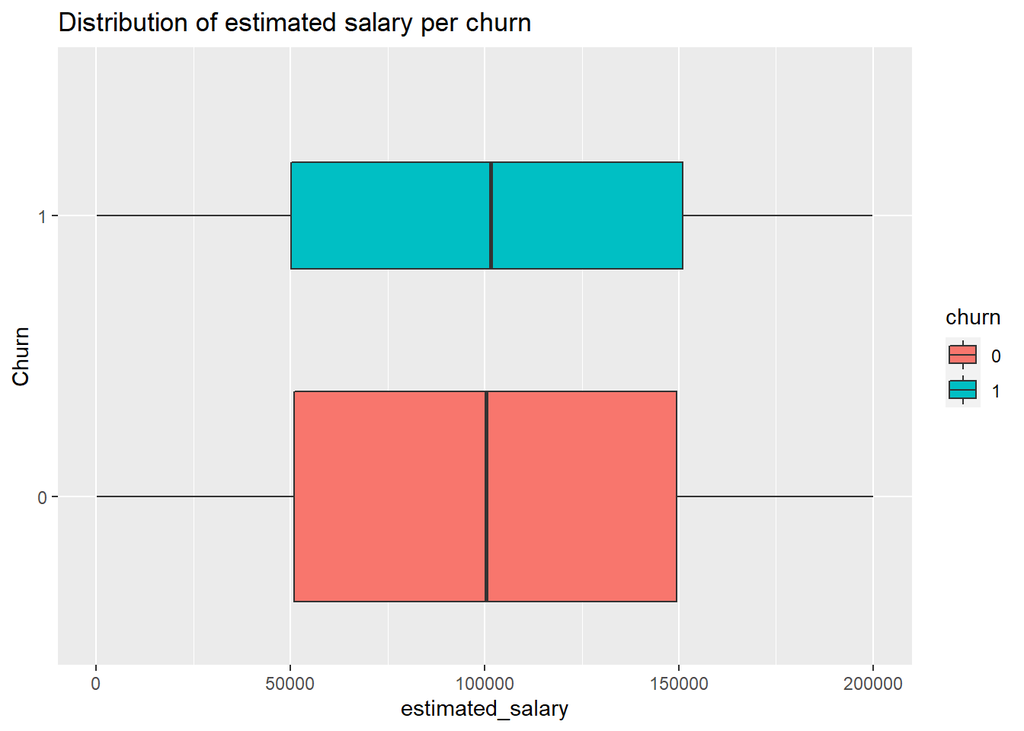

```r
ggplot(train_data, aes(reorder(churn, estimated_salary), estimated_salary,fill=churn)) +
  geom_boxplot(varwidth = TRUE) +
  coord_flip() +
  labs(
    title = "Distribution of estimated salary per churn",
    x = "Churn"
  )
```

#### Age Vs Estimated salary by product number

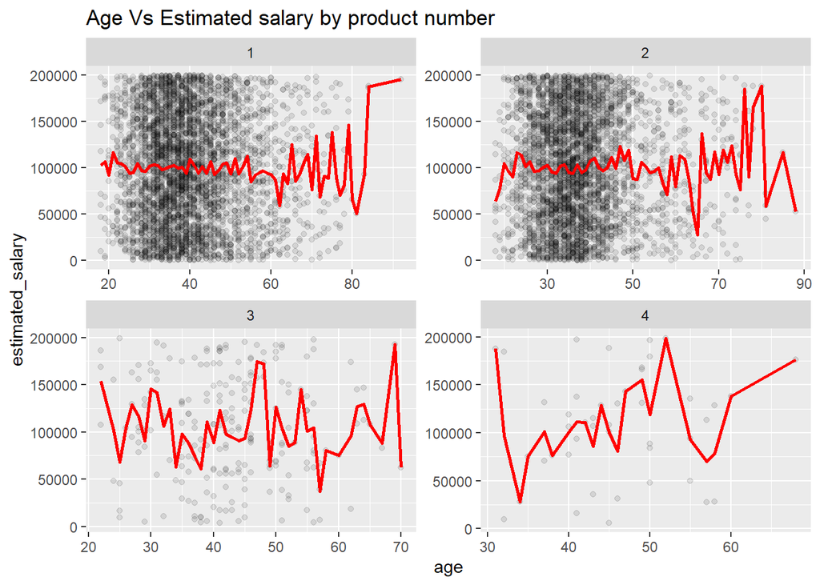

```r
train_data %>%
  ggplot(aes(age,estimated_salary)) +
  geom_point(alpha = 0.1) +
  stat_summary(fun.y=mean, colour="red", geom="line", size = 1)+
  facet_wrap(~products_number, scales = "free") +
  labs(
    title = "Age Vs Estimated salary by product number"
  )
```

#### Age Vs Estimated salary by country

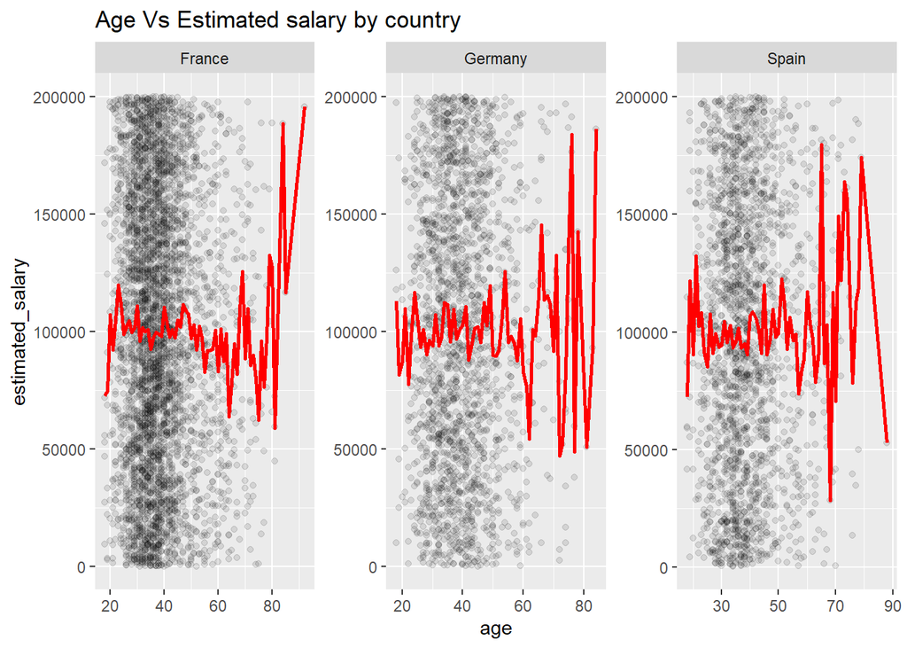

```r
train_data %>%
  ggplot(aes(age,estimated_salary)) +
  geom_point(alpha = 0.1) +
  stat_summary(fun.y=mean, colour="red", geom="line", size = 1)+
  facet_wrap(~country, scales = "free") +
  labs(
    title = "Age Vs Estimated salary by country"
  )
```

#### Age Vs Estimated salary by churn

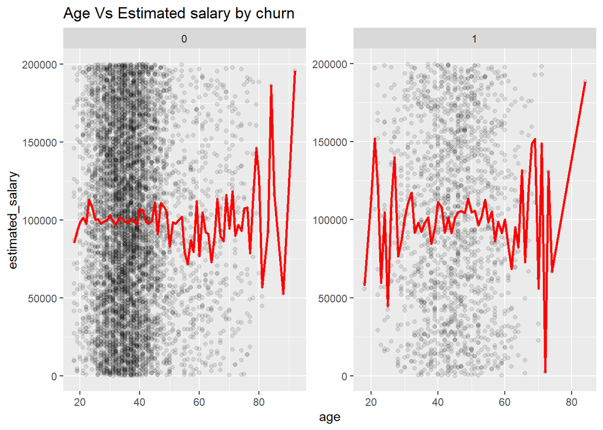

```r
train_data %>%
  ggplot(aes(age,estimated_salary)) +
  geom_point(alpha = 0.1) +
  stat_summary(fun.y=mean, colour="red", geom="line", size = 1)+
  facet_wrap(~churn, scales = "free") +
  labs(
    title = "Age Vs Estimated salary by churn"
  )
```

There seems to have no relationship between the age of the customer and the estimated salary.If there exist a relationship,it might be very insignificant negative relationship between the duo. We expect the very young people to have very low salaries since their education qualification might differ with age. However,since the banks can control the age of its customers,it seems that almost all customers lie in the same age group,meaning that they have almost average salary. This explains why the plots irrespective of any category shows no relationship between the age and salary of a customer.

#### Age Vs balance by product number

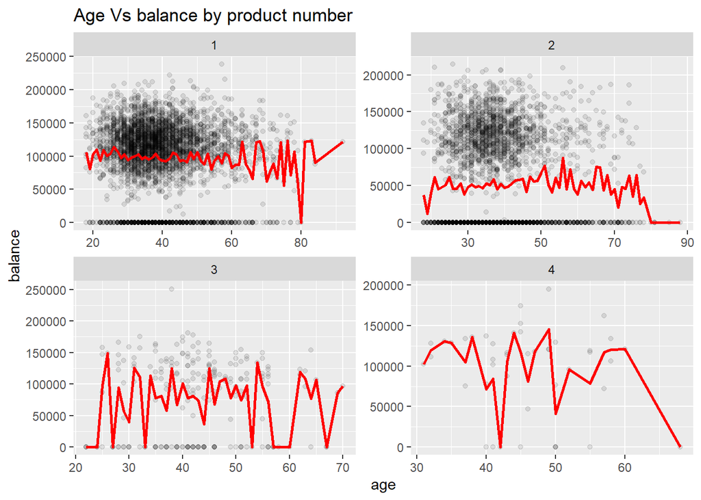

```r
train_data %>%
  ggplot(aes(age,balance)) +
  geom_point(alpha = 0.1) +
  stat_summary(fun.y=mean, colour="red", geom="line", size = 1)+
  facet_wrap(~products_number, scales = "free") +
  labs(
    title = "Age Vs balance by product number"
  )
```

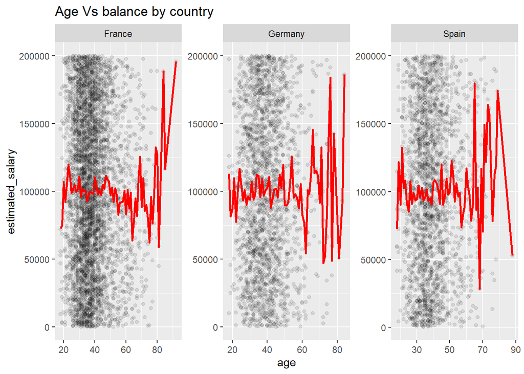

```r
train_data %>%
  ggplot(aes(age,estimated_salary)) +
  geom_point(alpha = 0.1) +
  stat_summary(fun.y=mean, colour="red", geom="line", size = 1)+
  facet_wrap(~country, scales = "free") +
  labs(
    title = "Age Vs balance by country"
  )
```

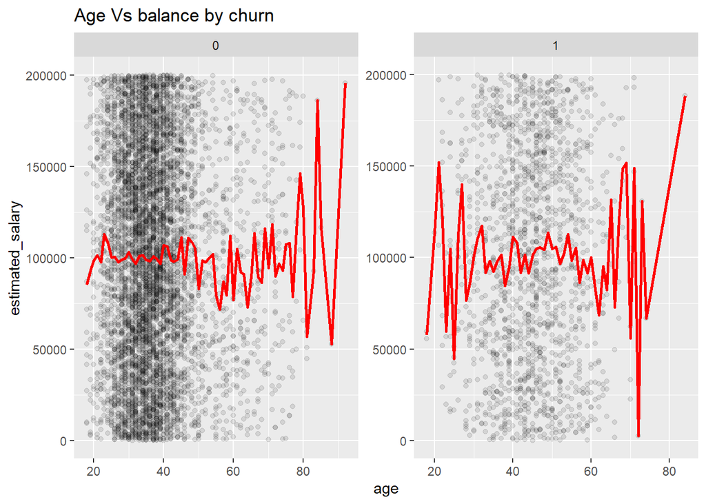

```r
train_data %>%
  ggplot(aes(age,estimated_salary)) +
  geom_point(alpha = 0.1) +
  stat_summary(fun.y=mean, colour="red", geom="line", size = 1)+
  facet_wrap(~churn, scales = "free") +
  labs(
    title = "Age Vs balance by churn"
  )
```

Note that,the relationship between the age of a customer and the balance he/she has is insignificant. If there,then it might be very minimal positive relationship. Similary to relationship between age and salary,the banks control for age of its customers. this might explain as to why relations lacks.

### Is churn different in those countries?

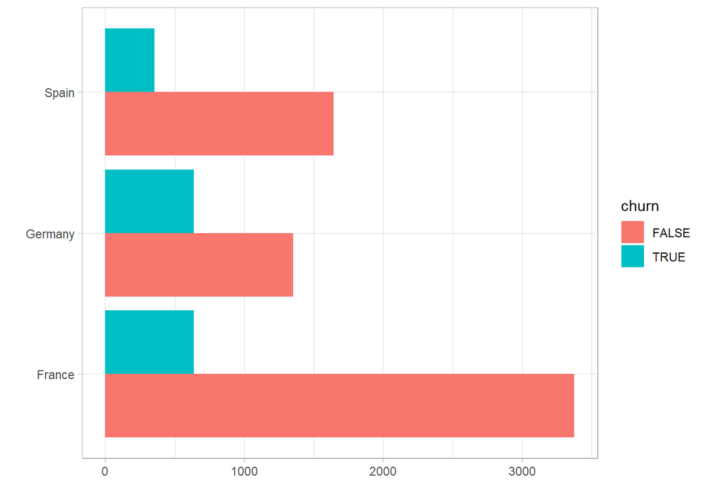

```r
train_data %>%
  mutate(churn = if_else(churn == "1", TRUE, FALSE)) %>%
  count(country, churn) %>%
  ggplot()+
  aes(country, n, fill = churn)+
  geom_col(position = "dodge")+
  labs(x = "", y  ="")+
  theme_light()+
  coord_flip()
```

As we can see churn in Germany proportionally higher than France and Spain. This has enforced Germany to workout on ways to manage this churn. Germany’s financial services market is very crowded, therefore it might be difficult for established businesses to differentiate their service offerings. Due to a large selection of alternative financial products and competing providers, the percentage of customers transferring to other financial service providers has increased dramatically. Because of this, client churn rates have increased recently. This has highlighted the value of churn analysis and its function in retaining customers. Additionally, research indicate that substantial expenditures in the form of lost earnings have been associated with customer churn. This denotes a loss of revenue from both the customers themselves and from other value-added contributors.

Due to the complexity of the datasets, the client, a top German banking firm, found it difficult to pinpoint the cause of customer churn. The client was also looking for appropriate churn analysis models to aid in understanding different customer groups’ preferences and determining the risk of churn that went along with them.

In order to analyze scenarios, foresee hazards, forecast resources, balance risks against projected profits, and endeavor to satisfy regulatory requirements, the German banking institution partnered with Quantzig to take use of its expertise in providing customer churn analytics solutions. The client was able to improve customer retention by 85%, decrease customer churn from 10% to 3%, and increase overall annual ROI by 70% because to Quantzig’s customer churn analysis engagement.

### Does the product number affect churn

The bank has four product which a customer can choose from. Let’s evaluate whether the type of product affects churn.

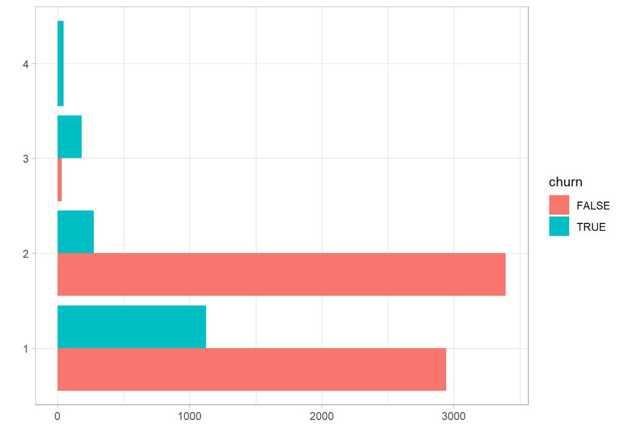

```r
train_data %>%
  mutate(churn = if_else(churn == "1", TRUE, FALSE)) %>%
  count(products_number, churn) %>%
  ggplot()+
  aes(products_number, n, fill = churn)+
  geom_col(position = "dodge")+
  labs(x = "", y  ="")+
  theme_light()+
  coord_flip()
```

First, products 3 and 4 do not have many customers. Moreover, the churn is higher than any of the current clients. This could possibly signify that product is not very popular with customer. Another probability is that they migrated to product 1 and 2 which have proportionally lower churn. However, product 2 is the most liked with the lowest churn.

### Does the fact that a customer is active or not affect the churn

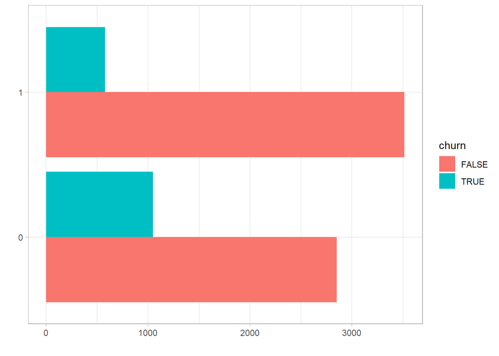

```r
train_data %>%
  mutate(churn = if_else(churn == "1", TRUE, FALSE)) %>%
  count(active_member, churn) %>%
  ggplot()+
  aes(active_member, n, fill = churn)+
  geom_col(position = "dodge")+
  labs(x = "", y  ="")+
  theme_light()+
  coord_flip()
```

### Does gender affect the churn?

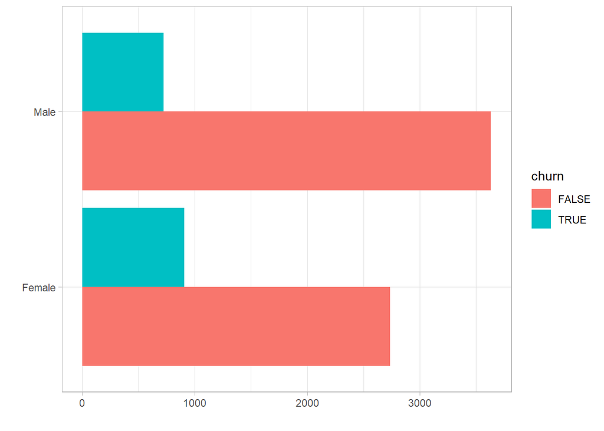

```r
train_data %>%
  mutate(churn = if_else(churn == "1", TRUE, FALSE)) %>%
  count(gender, churn) %>%
  ggplot()+
  aes(gender, n, fill = churn)+
  geom_col(position = "dodge")+
  labs(x = "", y  ="")+
  theme_light()+
  coord_flip()
```

Although the frequency of leaver in both gender is almost similar the proportion is significantly lower for males. Hence, there is a clear difference between genders. Women more like would leave the bank than men.

### Diffrence in Age distributions for people who left the and those who stayed

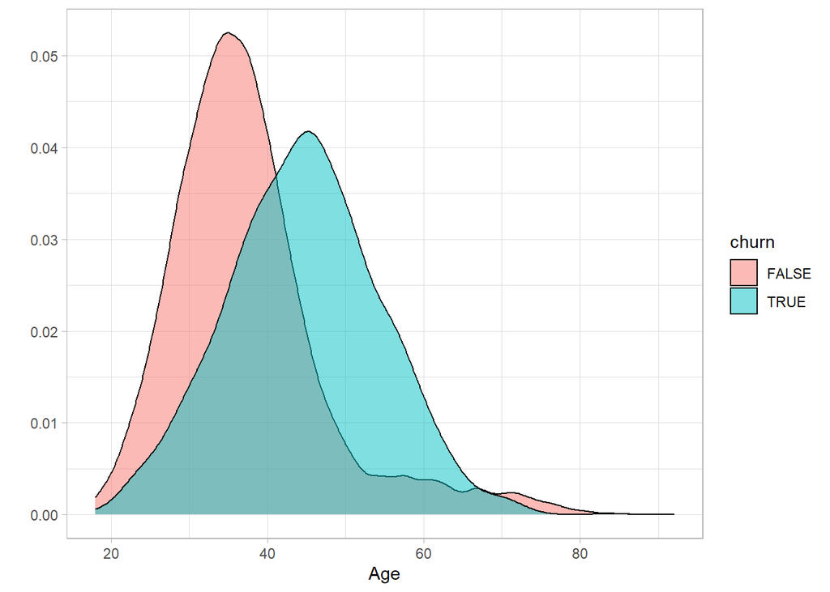

```r
train_data %>%
  mutate(churn = if_else(churn == "1", TRUE, FALSE)) %>%
  ggplot()+
  aes(age, fill = churn)+
  geom_density(alpha = 0.5)+
  theme_light()+
  labs(x = "Age", y  ="")
```

### Does balance of the client affect churn rate?

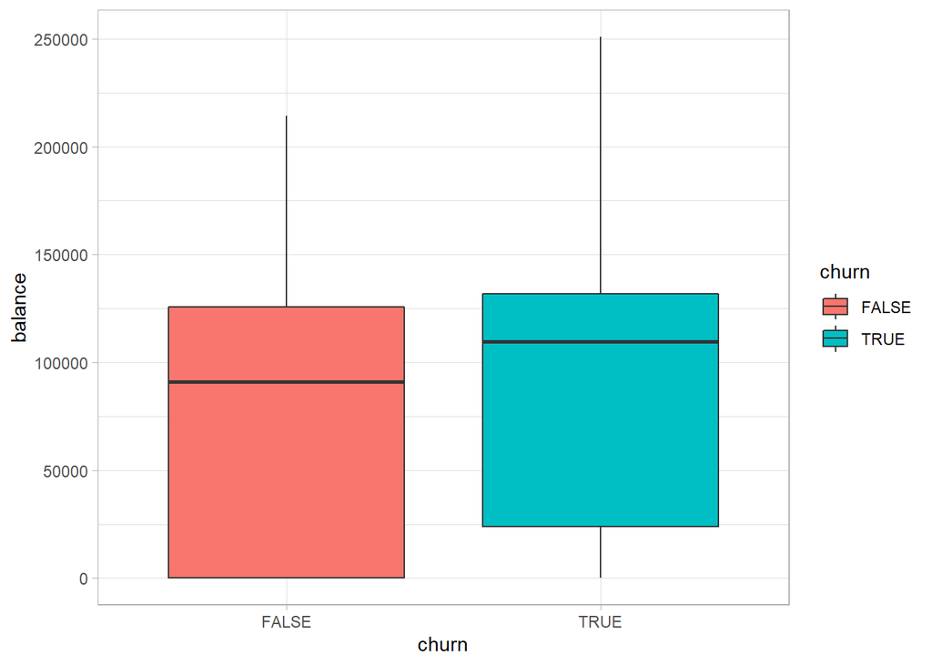

```r
train_data %>%
  mutate(churn = if_else(churn == "1", TRUE, FALSE)) %>%
  ggplot()+
  aes(balance, churn, fill = churn)+
  geom_boxplot()+
  # facet_wrap(~country)+
  theme_light()+
  coord_flip()
```

Accounts with balances equal zero skew the data, lets look at non zero balances

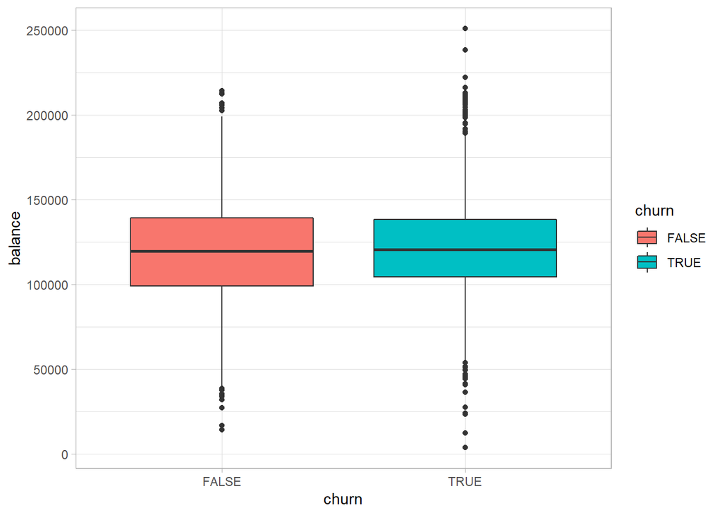

```r
train_data %>%
  mutate(churn = if_else(churn == "1", TRUE, FALSE)) %>%
  filter(balance != 0) %>%
  ggplot()+
  aes(balance, churn, fill = churn)+
  geom_boxplot()+
  # facet_wrap(~country)+
  theme_light()+
  coord_flip()
```

There are no meaningful difference in distributions. May be there is difference for genders or countries?

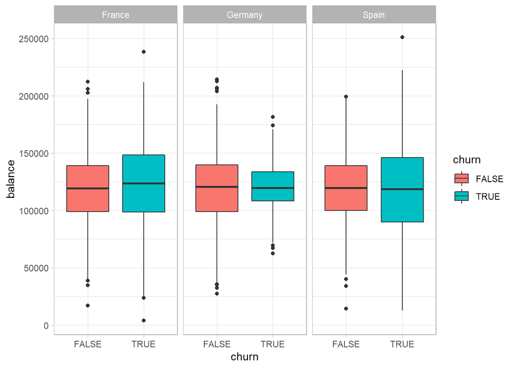

```r
train_data %>%
  mutate(churn = if_else(churn == "1", TRUE, FALSE)) %>%
  filter(balance != 0) %>%
  ggplot()+
  aes(balance, churn, fill = churn)+
  geom_boxplot()+
  facet_wrap(~country)+
  theme_light()+
  coord_flip()
```

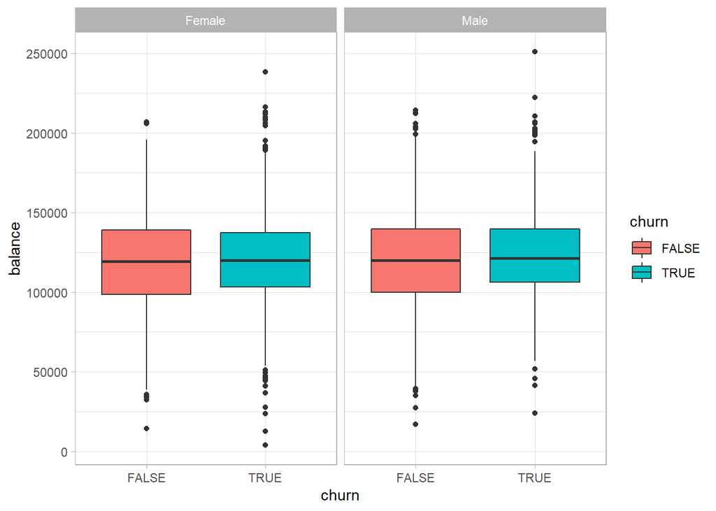

```r
train_data %>%
  mutate(churn = if_else(churn == "1", TRUE, FALSE)) %>%
  filter(balance != 0) %>%
  ggplot()+
  aes(balance, churn, fill = churn)+
  geom_boxplot()+
  facet_wrap(~gender)+
  theme_light()+
  coord_flip()
```

The boxplot represent the interaction between the churn and the other two variables, churn and gender. Clearly, the account balance is not statistically significant in explaining the Churn rate.

### Is having a credit card would affect churn?

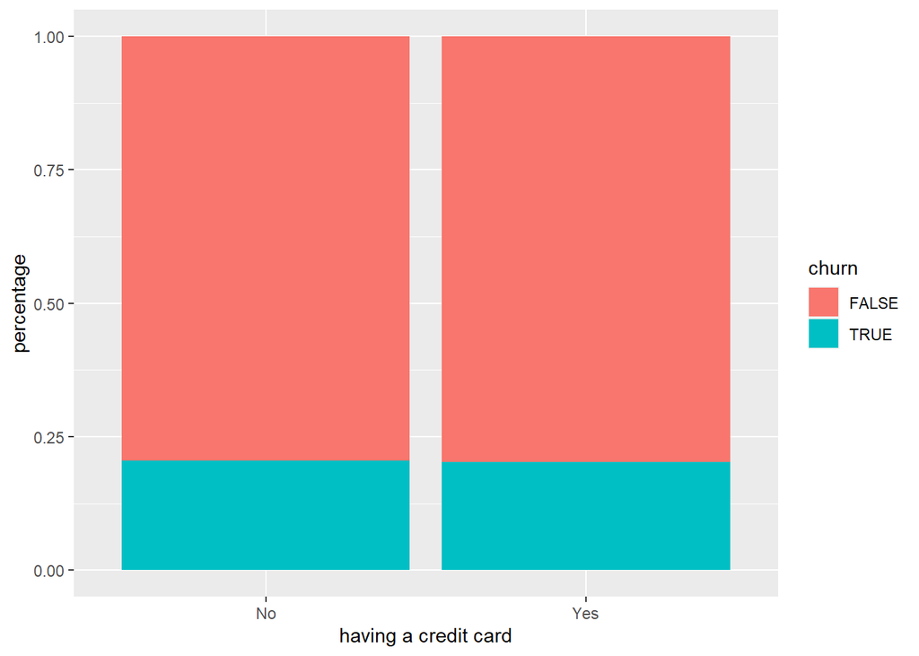

```r
train_data %>%
  mutate(churn = if_else(churn == "1", TRUE, FALSE)) %>%
  mutate(credit_card = if_else(credit_card == "1", "Yes", "No")) %>%
  count(credit_card, churn) %>%
  ggplot()+
  aes(credit_card, n, fill = churn)+
  geom_col(position = "fill")+
  labs(y = "percentage", x = "having a credit card")
```

Looks like there is no difference hence possession of a credit is not significantly associated to the churn rate.

### Does income affect rate of churn?

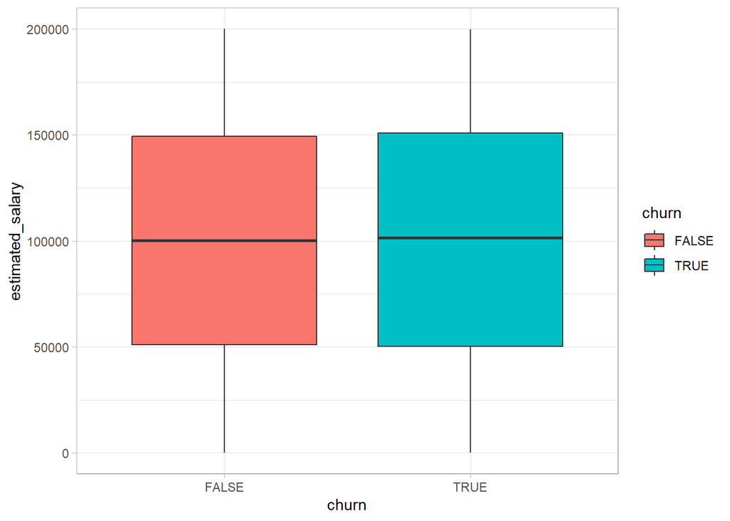

```r
train_data %>%
  mutate(churn = if_else(churn == "1", TRUE, FALSE)) %>%
  ggplot()+
  aes(estimated_salary, churn, fill = churn)+
  geom_boxplot()+
  theme_light()+
  coord_flip()
```

Nope.

Looks like there is no difference in the income since the mean of both groups are the same. In this case the EDA was important because it assisted in identifying significant variables that can be used in building the models. Using a lot of variables usually leads to over fitting. Although, a model with a high fit can explain a lot of variation in data, its prediction accuracy is reduced.

# Statistical Analysis

### Recipe

First lets create a recipe for our data. Recipes provide an alternate approach for building and preprocessing design matrices that can be used for modeling or visualization.

```r
train_data$tenurre<-NULL
set.seed(421)
recipe(churn ~ ., train_data) %>%
  # encode factors with one hot encoder
  step_dummy(all_nominal(), -all_outcomes(), one_hot = TRUE) %>%
  # normalize all predictor
  step_center(all_predictors()) %>%
  step_scale(all_predictors()) %>%
  # upscale churn variable with smote algorithm
  step_smote(all_outcomes()) -> rec_obj
```

### Cross - validation splits

```r
folds <- vfold_cv(train_data, v = 5)
```

### Specs

In this part, we are going to develop models and the processes that go along with the recipe that we have.

#### Logistic regression

Logistic Regression is a method for categorizing data that is utilized by machine learning systems. This statistical method involves doing the analysis of a dataset that contains one or more independent variables. Logistic regression is used to identify which model is most suitable for characterizing the connection between a dependent and an independent variable. The model that is determined to be most suitable is determined via the use of logistic regression. A logistic function is used as a modeling tool for the dependent variable in this scenario. The dependent variable is binary, which means that there are only two possible categories to be taken into consideration. Within this context, the value of churn might either be 0 or 1. As a result, this approach is utilized whenever one is dealing with binary information.

Model’s specs: We dont have a lot of dependent variables so ridge regression(mixture = 0) is sufficient for the task. Also we will tune the amount of regularization for the model(penalty).

```r
logreg <- logistic_reg(
  mode = "classification",
  engine = "glmnet",
  penalty = tune(), mixture = 0)

# our workflow based on our recipe and model
w_log <- workflow() %>%
  add_recipe(rec_obj) %>%
  add_model(logreg)
```

#### Random Forest model

Another classifier model utilized in the project is the random forest. Random forest is an assembly of several different decision trees that are all independent of one another, as its name suggests. Each random forest tree provides a prediction regarding the classification, and the final classification is determined based on which predictions receive the most votes. It is a meta-estimator that works by fitting several decision tree classifiers on distinct subsamples of the dataset in order to increase predicted accuracy and regulate over-fitting. This is accomplished via the use of averaging.

Lets try random forest

```r
rf_model <- rand_forest(
  mode = "classification",
  engine = "ranger",
  trees = 100,
  mtry = tune(),
  min_n = tune())

w_rf <- workflow() %>%
  add_recipe(rec_obj) %>%
  add_model(rf_model)
```

#### Bosted tree model

Models using a boosted regression tree (BRT) combine decision tree algorithms with boosting techniques. Similar to the Random Forest model, BRTs involve fitting several decision trees in order to fine-tune the model’s performance. The selection criteria for the data used in the tree-building processes is one area where these two approaches diverge. For each new tree constructed, both methods select a portion of the data at random. Every sample taken at random contains the same amount of records as the full dataset. Data that is picked in one tree can be returned to the complete dataset for use in another. BRTs use the boosting approach, in which the input data are weighted in successive trees, as opposed to the bagging method employed by Random Forest models, which assigns equal likelihood to each occurrence in future sample selections. Data that was poorly modeled by earlier trees has a greater chance of being picked in the current tree due to the weights. Thus, the model will account for the mistake in the forecast of the first tree when fitting the second tree, and so on. The model constantly strives for better accuracy by considering the fit of previously constructed trees. Boosting is the only technique that uses this method of successive steps.

```r
bt_tune_model <- boost_tree(mode = "classification", engine = "xgboost",
                       mtry = 5,
                       min_n = tune(),
                       tree_depth = tune(),
                       learn_rate = tune(),
                       loss_reduction = tune(),
                       sample_size = tune(),
                       trees = 100)
w_tune_bt <- workflow() %>%
  add_recipe(rec_obj) %>%
  add_model(bt_tune_model)
```

#### Knn model

The initials KNN refer to the “K-Nearest Neighbor” algorithm. For each new, unclassified, and unpredicted variable, K represents the number of its nearest neighbors. Let’s examine a relevant real-world case in depth before we dive into this fantastic method. We often hear that you and the people in your immediate social circle share a great deal in common, whether it’s a way of thinking, a set of values, a set of work habits, or anything else. Because of this, we tend to form relationships with those who we see as being most like ourselves. This is also the underlying idea behind the KNN algorithm. This method seeks to identify the nearest neighbors of a new, unclassified data item. This strategy is distance-based.

```r
knn_model <- nearest_neighbor(mode = "classification",
                              neighbors = tune(),
                              engine = "kknn")
w_knn <- workflow() %>%
  add_recipe(rec_obj) %>%
  add_model(knn_model)
```